# matplotlib.figure.Figure.add_axes

**Figure.add_axes(*args, **kwargs)[[source]](https://github.com/matplotlib/matplotlib/blob/v3.10.8/lib/matplotlib/figure.py#L531-L642)**

Add an `Axes` to the figure.

Call signatures:

```
add_axes(rect, projection=None, polar=False, **kwargs)
add_axes(ax)
```

**Parameters:**

**rect**tuple (left, bottom, width, height)**

The dimensions (left, bottom, width, height) of the new `Axes`. All quantities are in fractions of figure width and height.

**projection**{None, 'aitoff', 'hammer', 'lambert', 'mollweide', 'polar', 'rectilinear', str}, optional**

The projection type of the `Axes`. *str* is the name of a custom projection, see `projections`. The default None results in a 'rectilinear' projection.

**polar**bool, default: False**

If True, equivalent to projection='polar'.

**axes_class**subclass type of `Axes`, optional**

The `axes.Axes` subclass that is instantiated. This parameter is incompatible with *projection* and *polar*. See [axisartist](https://matplotlib.org/stable/users/explain/toolkits/axisartist.html#axisartist-users-guide-index) for examples.

**sharex, sharey**`Axes`, optional**

Share the x or y `axis` with sharex and/or sharey. The axis will have the same limits, ticks, and scale as the axis of the shared Axes.

**label**str**

A label for the returned Axes.

**Returns:**

**`Axes`, or a subclass of `Axes`**

The returned Axes class depends on the projection used. It is `Axes` if rectilinear projection is used and `projections.polar.PolarAxes` if polar projection is used.

**Other Parameters:**

**kwargs**

This method also takes the keyword arguments for the returned Axes class. The keyword arguments for the rectilinear Axes class `Axes` can be found in the following table but there might also be other keyword arguments if another projection is used, see the actual Axes class.

| Property | Description |
| --- | --- |
| `adjustable` | {'box', 'datalim'} |
| `agg_filter` | a filter function, which takes a (m, n, 3) float array and a dpi value, and returns a (m, n, 3) array and two offsets from the bottom left corner of the image |
| `alpha` | float or None |
| `anchor` | (float, float) or {'C', 'SW', 'S', 'SE', 'E', 'NE', ...} |
| `animated` | bool |
| `aspect` | {'auto', 'equal'} or float |
| `autoscale_on` | bool |
| `autoscalex_on` | unknown |
| `autoscaley_on` | unknown |
| `axes_locator` | Callable[[Axes, Renderer], Bbox] |
| `axisbelow` | bool or 'line' |
| `box_aspect` | float or None |
| `clip_box` | `BboxBase` or None |
| `clip_on` | bool |
| `clip_path` | Patch or (Path, Transform) or None |
| `facecolor` or `fc` | [color](https://matplotlib.org/stable/users/explain/colors/colors.html#colors-def) |
| `figure` | `Figure` or `SubFigure` |
| `forward_navigation_events` | bool or "auto" |
| `frame_on` | bool |
| `gid` | str |
| `in_layout` | bool |
| `label` | object |
| `mouseover` | bool |
| `navigate` | bool |
| `navigate_mode` | unknown |
| `path_effects` | list of `AbstractPathEffect` |
| `picker` | None or bool or float or callable |
| `position` | [left, bottom, width, height] or `Bbox` |
| `prop_cycle` | [`Cycler`](https://matplotlib.org/cycler/generated/cycler.Cycler.html#cycler.Cycler) |
| `rasterization_zorder` | float or None |
| `rasterized` | bool |
| `sketch_params` | (scale: float, length: float, randomness: float) |
| `snap` | bool or None |
| `subplotspec` | unknown |
| `title` | str |
| `transform` | `Transform` |
| `url` | str |
| `visible` | bool |
| `xbound` | (lower: float, upper: float) |
| `xlabel` | str |
| `xlim` | (left: float, right: float) |
| `xmargin` | float greater than -0.5 |
| `xscale` | unknown |
| `xticklabels` | unknown |
| `xticks` | unknown |
| `ybound` | (lower: float, upper: float) |
| `ylabel` | str |
| `ylim` | (bottom: float, top: float) |
| `ymargin` | float greater than -0.5 |
| `yscale` | unknown |
| `yticklabels` | unknown |
| `yticks` | unknown |
| `zorder` | float |

See also

**`Figure.add_subplot`**

**`pyplot.subplot`**

**`pyplot.axes`**

**`Figure.subplots`**

**`pyplot.subplots`**

#### Notes

In rare circumstances, `add_axes` may be called with a single argument, an Axes instance already created in the present figure but not in the figure's list of Axes.

#### Examples

Some simple examples:

```
rect = l, b, w, h
fig = plt.figure()
fig.add_axes(rect)
fig.add_axes(rect, frameon=False, facecolor='g')
fig.add_axes(rect, polar=True)
ax = fig.add_axes(rect, projection='polar')
fig.delaxes(ax)
fig.add_axes(ax)
```

## Examples using `matplotlib.figure.Figure.add_axes`

[figure not shown]

[Rain simulation](https://matplotlib.org/stable/gallery/animation/rain.html)

Rain simulation

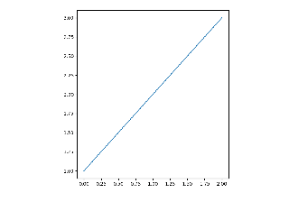

[Axes with a fixed physical size](https://matplotlib.org/stable/gallery/axes_grid1/demo_fixed_size_axes.html)

Axes with a fixed physical size

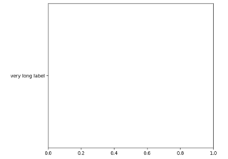

[Make room for ylabel using axes_grid](https://matplotlib.org/stable/gallery/axes_grid1/make_room_for_ylabel_using_axesgrid.html)

Make room for ylabel using axes_grid

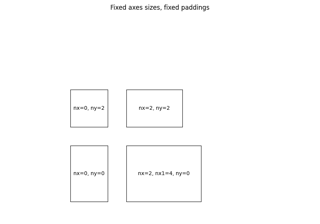

[Simple Axes Divider 1](https://matplotlib.org/stable/gallery/axes_grid1/simple_axes_divider1.html)

Simple Axes Divider 1

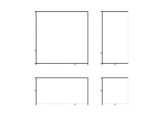

[Simple axes divider 3](https://matplotlib.org/stable/gallery/axes_grid1/simple_axes_divider3.html)

Simple axes divider 3

[Parasite Axes demo](https://matplotlib.org/stable/gallery/axisartist/demo_parasite_axes.html)

Parasite Axes demo

[Barcode](https://matplotlib.org/stable/gallery/images_contours_and_fields/barcode_demo.html)

Barcode

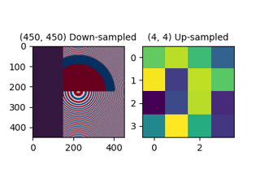

[Image resampling](https://matplotlib.org/stable/gallery/images_contours_and_fields/image_antialiasing.html)

Image resampling

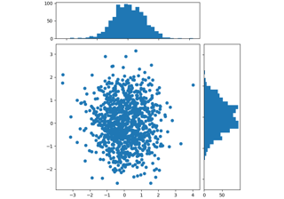

[Scatter plot with histograms](https://matplotlib.org/stable/gallery/lines_bars_and_markers/scatter_hist.html)

Scatter plot with histograms

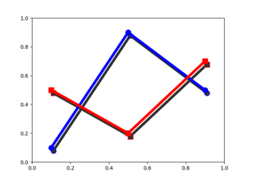

[Apply SVG filter to a line](https://matplotlib.org/stable/gallery/misc/svg_filter_line.html)

Apply SVG filter to a line

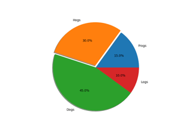

[SVG filter pie](https://matplotlib.org/stable/gallery/misc/svg_filter_pie.html)

SVG filter pie

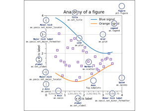

[Anatomy of a figure](https://matplotlib.org/stable/gallery/showcase/anatomy.html)

Anatomy of a figure

[figure not shown]

[Firefox](https://matplotlib.org/stable/gallery/showcase/firefox.html)

Firefox

[figure not shown]

[Shaded & power normalized rendering](https://matplotlib.org/stable/gallery/showcase/mandelbrot.html)

Shaded & power normalized rendering

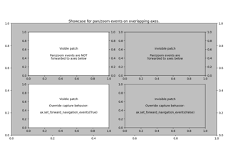

[Pan/zoom events of overlapping axes](https://matplotlib.org/stable/gallery/showcase/pan_zoom_overlap.html)

Pan/zoom events of overlapping axes

[figure not shown]

[XKCD](https://matplotlib.org/stable/gallery/showcase/xkcd.html)

XKCD

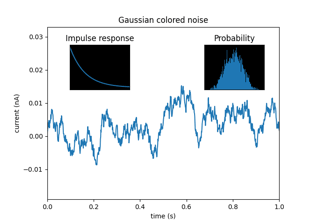

[Axes Demo](https://matplotlib.org/stable/gallery/subplots_axes_and_figures/axes_demo.html)

Axes Demo

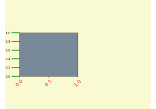

[Fig Axes Customize Simple](https://matplotlib.org/stable/gallery/ticks/fig_axes_customize_simple.html)

Fig Axes Customize Simple

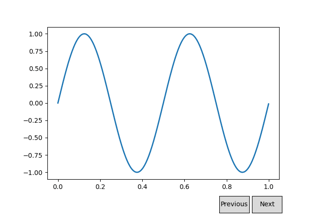

[Buttons](https://matplotlib.org/stable/gallery/widgets/buttons.html)

Buttons

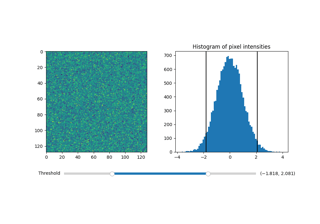

[Image scaling using a RangeSlider](https://matplotlib.org/stable/gallery/widgets/range_slider.html)

Image scaling using a RangeSlider

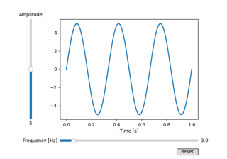

[Slider](https://matplotlib.org/stable/gallery/widgets/slider_demo.html)

Slider

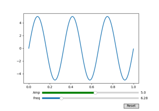

[Snap sliders to discrete values](https://matplotlib.org/stable/gallery/widgets/slider_snap_demo.html)

Snap sliders to discrete values

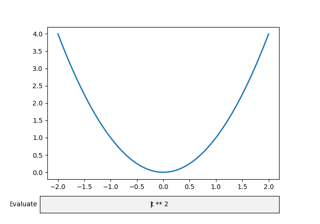

[Textbox](https://matplotlib.org/stable/gallery/widgets/textbox.html)

Textbox

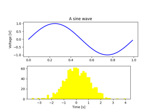

[Artist tutorial](https://matplotlib.org/stable/tutorials/artists.html)

Artist tutorial

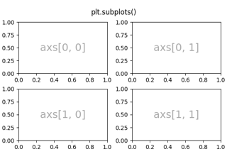

[Arranging multiple Axes in a Figure](https://matplotlib.org/stable/users/explain/axes/arranging_axes.html)

Arranging multiple Axes in a Figure

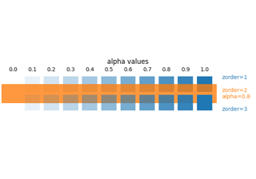

[Specifying colors](https://matplotlib.org/stable/users/explain/colors/colors.html)

Specifying colors

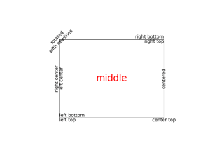

[Text properties and layout](https://matplotlib.org/stable/users/explain/text/text_props.html)

Text properties and layout